# Exercícios - Regressão Linear Múltipla em R

04-11-2025

## Pacotes e dados

```r
# Instalar se necessário:
req <- c("tidyverse","broom","palmerpenguins","nycflights13","car","performance","GGally", "see")
new <- setdiff(req, rownames(installed.packages()))
if(length(new)) install.packages(new)

library(tidyverse)
library(broom)
library(palmerpenguins)
library(nycflights13)
library(car)           # VIF e diagnóstico
library(performance)   # checks de suposições
library(GGally)        # ggpairs
library(see)          # diagnóstico
```

## Conjunto de dados A: `penguins`

Descrição curta: pinguins de 3 espécies na Antártida, com medidas morfológicas e sexo.

```r
penguins <- palmerpenguins::penguins |> drop_na()
glimpse(penguins)
```

```
## Rows: 333
## Columns: 8
## $ species           <fct> Adelie, Adelie, Adelie, Adelie, Adelie, Adelie, Adel…
## $ island            <fct> Torgersen, Torgersen, Torgersen, Torgersen, Torgerse…
## $ bill_length_mm    <dbl> 39.1, 39.5, 40.3, 36.7, 39.3, 38.9, 39.2, 41.1, 38.6…
## $ bill_depth_mm     <dbl> 18.7, 17.4, 18.0, 19.3, 20.6, 17.8, 19.6, 17.6, 21.2…
## $ flipper_length_mm <int> 181, 186, 195, 193, 190, 181, 195, 182, 191, 198, 18…
## $ body_mass_g       <int> 3750, 3800, 3250, 3450, 3650, 3625, 4675, 3200, 3800…
## $ sex               <fct> male, female, female, female, male, female, male, fe…
## $ year              <int> 2007, 2007, 2007, 2007, 2007, 2007, 2007, 2007, 2007…
```

```r
summary(penguins)
```

```
##       species          island    bill_length_mm  bill_depth_mm
##  Adelie   :146   Biscoe   :163   Min.   :32.10   Min.   :13.10
##  Chinstrap: 68   Dream    :123   1st Qu.:39.50   1st Qu.:15.60
##  Gentoo   :119   Torgersen: 47   Median :44.50   Median :17.30
##                                  Mean   :43.99   Mean   :17.16
##                                  3rd Qu.:48.60   3rd Qu.:18.70
##                                  Max.   :59.60   Max.   :21.50
##  flipper_length_mm  body_mass_g       sex           year
##  Min.   :172       Min.   :2700   female:165   Min.   :2007
##  1st Qu.:190       1st Qu.:3550   male  :168   1st Qu.:2007
##  Median :197       Median :4050                Median :2008
##  Mean   :201       Mean   :4207                Mean   :2008
##  3rd Qu.:213       3rd Qu.:4775                3rd Qu.:2009
##  Max.   :231       Max.   :6300                Max.   :2009
```

## Conjunto de dados B: `nycflights13::flights`

Descrição curta: todos os voos a partir de NYC em 2013. Para tornar leve, usaremos uma amostra filtrada.

```r
flts <- nycflights13::flights |>
  filter(!is.na(dep_delay), !is.na(arr_delay),
         !is.na(distance), !is.na(air_time)) |>
  # amostra reprodutível
  slice_sample(n = 30000, replace = FALSE)
glimpse(flts)
```

```
## Rows: 30,000
## Columns: 19
## $ year           <int> 2013, 2013, 2013, 2013, 2013, 2013, 2013, 2013, 2013, 2…
## $ month          <int> 12, 9, 3, 2, 5, 10, 3, 10, 7, 6, 8, 2, 12, 9, 10, 12, 4…
## $ day            <int> 19, 17, 2, 1, 31, 7, 21, 4, 4, 4, 12, 15, 18, 10, 25, 2…
## $ dep_time       <int> 638, 1822, 834, 853, 1041, 1305, 1932, 1355, 853, 1423,…
## $ sched_dep_time <int> 645, 1829, 840, 759, 1046, 1248, 1915, 1359, 905, 1426,…
## $ dep_delay      <dbl> -7, -7, -6, 54, -5, 17, 17, -4, -12, -3, 52, 72, -4, -8…
## $ arr_time       <int> 844, 1928, 1009, 1103, 1145, 1524, 2203, 1537, 1027, 17…
## $ sched_arr_time <int> 840, 1939, 1030, 1025, 1205, 1450, 2202, 1605, 1111, 17…
## $ arr_delay      <dbl> 4, -11, -21, 38, -20, 34, 1, -28, -44, 5, 48, 45, -17, …
## $ carrier        <chr> "EV", "MQ", "MQ", "UA", "EV", "DL", "DL", "B6", "DL", "…
## $ flight         <int> 4099, 3044, 4521, 429, 4510, 1131, 1345, 1373, 181, 301…
## $ tailnum        <chr> "N13903", "N922MQ", "N737MQ", "N513UA", "N11565", "N342…
## $ origin         <chr> "EWR", "JFK", "LGA", "LGA", "EWR", "LGA", "JFK", "JFK",…
## $ dest           <chr> "STL", "BWI", "RDU", "DEN", "MKE", "DTW", "PHX", "CHS",…
## $ air_time       <dbl> 146, 45, 67, 228, 108, 95, 294, 87, 72, 149, 76, 41, 86…
## $ distance       <dbl> 872, 184, 431, 1620, 725, 502, 2153, 636, 502, 1069, 42…
## $ hour           <dbl> 6, 18, 8, 7, 10, 12, 19, 13, 9, 14, 14, 8, 8, 12, 13, 1…
## $ minute         <dbl> 45, 29, 40, 59, 46, 48, 15, 59, 5, 26, 55, 45, 29, 50, …
## $ time_hour      <dttm> 2013-12-19 06:00:00, 2013-09-17 18:00:00, 2013-03-02 0…
```

# Exercício 1 — Exploração inicial (EDA)

**1.1 (Penguins)** (a) Faça um *pair plot* das variáveis contínuas `bill_length_mm`, `bill_depth_mm`, `flipper_length_mm`, `body_mass_g` usando a função ggpairs do package GGally. (b) Calcule a matriz de correlações (com coeficiente de Pearson). (c) Comente potenciais colinearidades e relações com a resposta `body_mass_g`.

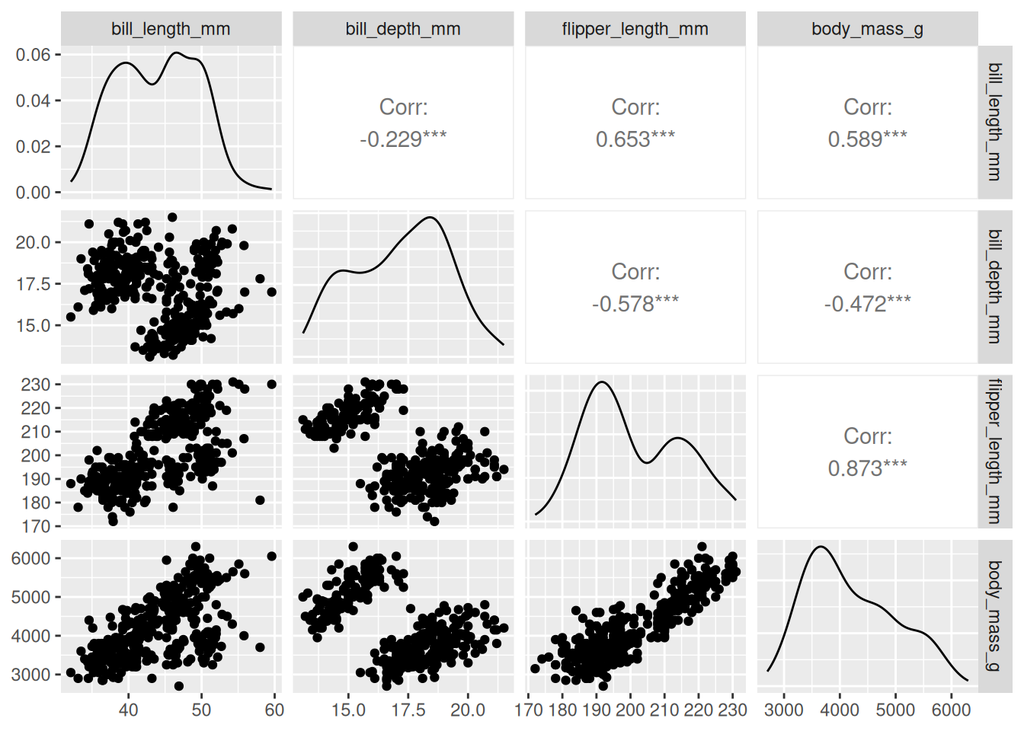

```r
#1
peng<-penguins|>select(bill_length_mm,bill_depth_mm,flipper_length_mm,body_mass_g)
ggpairs(peng)
```

```r
#2
cor<-cor(peng,method="pearson")
cor
```

```
##                   bill_length_mm bill_depth_mm flipper_length_mm body_mass_g
## bill_length_mm         1.0000000    -0.2286256         0.6530956   0.5894511
## bill_depth_mm         -0.2286256     1.0000000        -0.5777917  -0.4720157
## flipper_length_mm      0.6530956    -0.5777917         1.0000000   0.8729789
## body_mass_g            0.5894511    -0.4720157         0.8729789   1.0000000
```

```r
#3
#uma das princeipais colinearidades e o tamanho da flipper com base no peso do pinguim quanto mais pesado o pinguim maior a barbatana,tambem o tamanho do bico e algo com boa coliniaridade o mesmo aumenta conforme o peso
```

**1.2 (Flights)** (a) Faça um *pair plot* de `arr_delay` (resposta), `dep_delay`, `distance`, `air_time`. (b) Calcule correlações e comente.

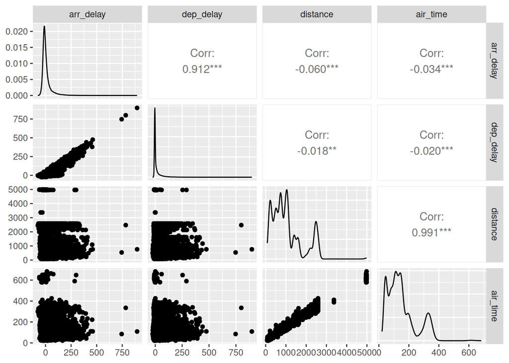

```r
#a
voadinha<-flts|>select(arr_delay,dep_delay,distance,air_time)
ggpairs(voadinha)
```

```r
#b
cor<-cor(voadinha,method='pearson')
cor
```

```
##             arr_delay   dep_delay    distance    air_time
## arr_delay  1.00000000  0.91183930 -0.06022897 -0.03380111
## dep_delay  0.91183930  1.00000000 -0.01800048 -0.01952937
## distance  -0.06022897 -0.01800048  1.00000000  0.99062913
## air_time  -0.03380111 -0.01952937  0.99062913  1.00000000
```

```r
#podemos observar correlaçao forte entre a resposta e a dep delay,podemos tambem observar o inverso,temos tambem uma correlaçao forte entre o tempo no ar e a distancia do voo
```

# Exercício 2 — Modelo base (Penguins)

**Objetivo:** modelar `body_mass_g` a partir de medidas do bico e da barbatana, controlando por espécie e sexo.

2.1. Ajuste o modelo:
$$\texttt{body_mass_g} \sim \texttt{bill_length_mm} +
\texttt{bill_depth_mm} * \texttt{flipper_length_mm} + \texttt{species} +
\texttt{sex}.$$

```r
mod<-lm(body_mass_g~bill_length_mm+bill_depth_mm*flipper_length_mm+species+sex,data=penguins)
mod
```

```
##
## Call:
## lm(formula = body_mass_g ~ bill_length_mm + bill_depth_mm * flipper_length_mm +
##     species + sex, data = penguins)
##
## Coefficients:
##                     (Intercept)                   bill_length_mm
##                      -3406.2424                          18.2860
##                   bill_depth_mm                flipper_length_mm
##                        175.5956                          25.8249
##                speciesChinstrap                    speciesGentoo
##                       -249.7808                         983.5141
##                         sexmale  bill_depth_mm:flipper_length_mm
##                        389.5287                          -0.5511
```

2.2. Interprete os coeficientes das variáveis contínuas (incluindo unidades) e o efeito marginal de `species` e `sex` (comparação com a categoria de referência). as duas com mais influencia no seu peso e entao a sua especeis com 983.514 sendo a especie gentoo,e tambem i seu sexo sendo mascolino tendo um impacto de 389.529

2.3. Calcule os **VIFs** e comente a multicolinearidade.

```r
vif<-vif(mod)
vif
```

```
##                                        GVIF Df GVIF^(1/(2*Df))
## bill_length_mm                     6.077481  1        2.465255
## bill_depth_mm                   1055.549521  1       32.489222
## flipper_length_mm                448.028796  1       21.166691
## species                           61.958849  2        2.805601
## sex                                2.309079  1        1.519565
## bill_depth_mm:flipper_length_mm  750.008960  1       27.386291
```

# Exercício 3 — Diagnóstico do modelo (Penguins)

3.1. Faça gráficos padrão de diagnóstico e comente: linearidade, homoscedasticidade, normalidade dos resíduos, pontos influentes. Depois experimente usar a função check_model do package performance.

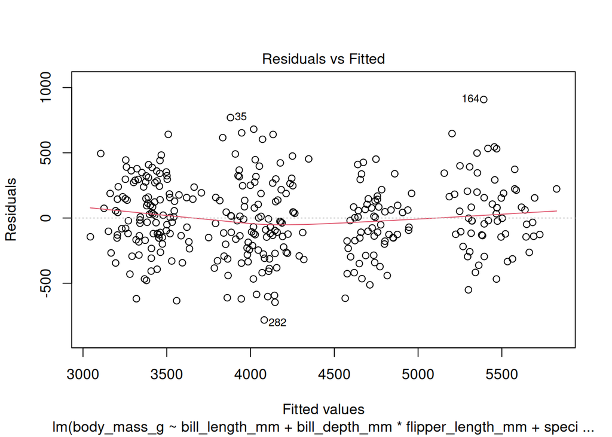

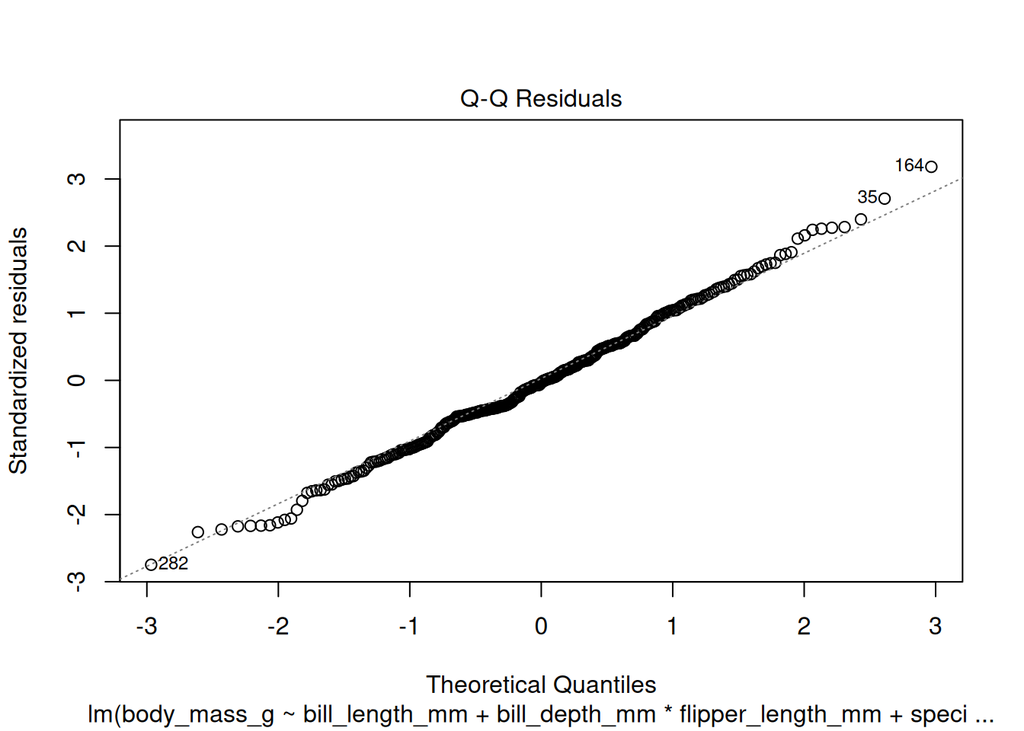

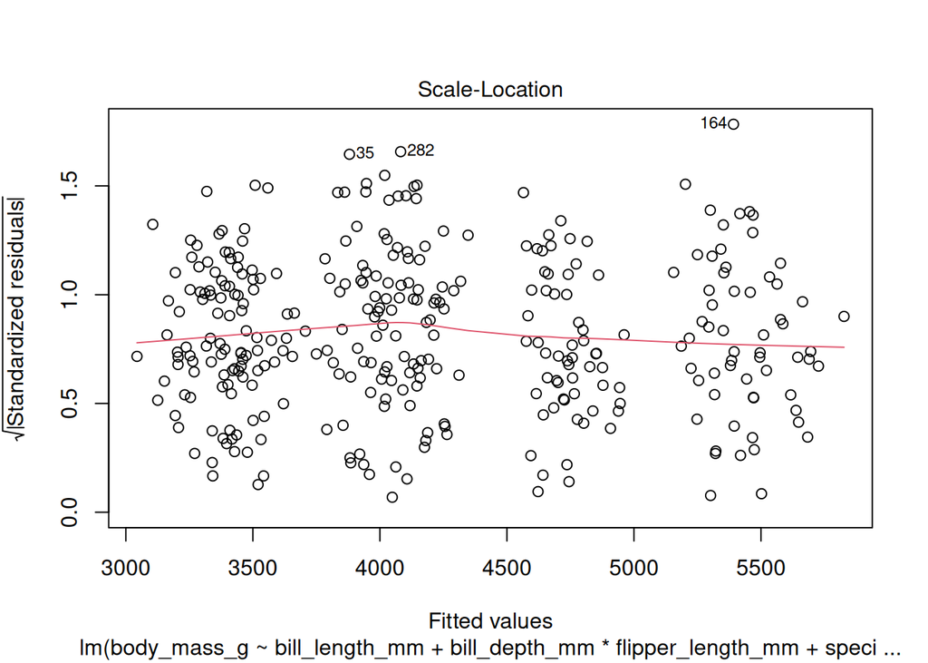

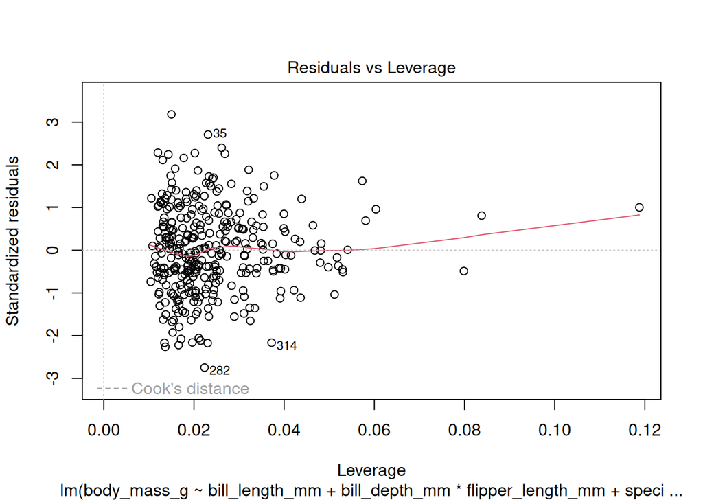

```r
plot(mod)
```

```r
par(mfrow = c(2,2))
par(mfrow = c(1,1))#perguntar a stora
```

3.2. Se necessário, proponha **transformações** (por ex., `log(body_mass_g)` ou padronizar os preditores). Ajuste o modelo transformado e compare AIC, BIC e R² ajustado.

```r
penguins<-penguins|>mutate(body_mass_g=log(body_mass_g))
mod_log<-lm(body_mass_g~bill_length_mm+bill_depth_mm*flipper_length_mm+species+sex,data=penguins)
summary(mod_log)
```

```
##
## Call:
## lm(formula = body_mass_g ~ bill_length_mm + bill_depth_mm * flipper_length_mm +
##     species + sex, data = penguins)
##
## Residuals:
##       Min        1Q    Median        3Q       Max
## -0.216851 -0.044974 -0.003232  0.043782  0.185864
##
## Coefficients:
##                                   Estimate Std. Error t value Pr(>|t|)
## (Intercept)                      5.4305988  1.1564137   4.696 3.92e-06 ***
## bill_length_mm                   0.0039551  0.0017524   2.257   0.0247 *
## bill_depth_mm                    0.1057170  0.0641340   1.648   0.1002
## flipper_length_mm                0.0115091  0.0058706   1.960   0.0508 .
## speciesChinstrap                -0.0497428  0.0200112  -2.486   0.0134 *
## speciesGentoo                    0.2256123  0.0368375   6.125 2.62e-09 ***
## sexmale                          0.0920942  0.0117967   7.807 8.13e-14 ***
## bill_depth_mm:flipper_length_mm -0.0004434  0.0003252  -1.364   0.1736
## ---
## Signif. codes:  0 '***' 0.001 '**' 0.01 '*' 0.05 '.' 0.1 ' ' 1
##
## Residual standard error: 0.07083 on 325 degrees of freedom
## Multiple R-squared:  0.8617, Adjusted R-squared:  0.8588
## F-statistic: 289.4 on 7 and 325 DF,  p-value: < 2.2e-16
```

```r
list(
  base = list(AIC = AIC(mod), BIC = BIC(mod), R2adj = summary(mod)$adj.r.squared),
  log  = list(AIC = AIC(mod_log), BIC = BIC(mod_log), R2adj = summary(mod_log)$adj.r.squared)
)
```

```
## $base
## $base$AIC
## [1] 4725.76
##
## $base$BIC
## [1] 4760.033
##
## $base$R2adj
## [1] 0.8723372
##
##
## $log
## $log$AIC
## [1] -808.3033
##
## $log$BIC
## [1] -774.0301
##
## $log$R2adj
## [1] 0.8587559
```

```r
#perguntar se maior melhor?
```

# Exercício 4 — Interações (Penguins)

4.1. Teste se o efeito de `flipper_length_mm` **varia por espécie**: inclua a interação `flipper_length_mm:species`.

```r
mod2<-lm(body_mass_g~bill_length_mm+bill_depth_mm+flipper_length_mm*species+sex,data=penguins)
summary(mod2)
```

```
##
## Call:
## lm(formula = body_mass_g ~ bill_length_mm + bill_depth_mm + flipper_length_mm *
##     species + sex, data = penguins)
##
## Residuals:
##       Min        1Q    Median        3Q       Max
## -0.219415 -0.044981 -0.000456  0.047714  0.197252
##
## Coefficients:
##                                      Estimate Std. Error t value Pr(>|t|)
## (Intercept)                         6.7882212  0.1919712  35.361  < 2e-16 ***
## bill_length_mm                      0.0042066  0.0017679   2.380 0.017914 *
## bill_depth_mm                       0.0189464  0.0048765   3.885 0.000124 ***
## flipper_length_mm                   0.0045474  0.0009475   4.799 2.43e-06 ***
## speciesChinstrap                    0.3110839  0.2949430   1.055 0.292337
## speciesGentoo                       0.6451566  0.2843151   2.269 0.023916 *
## sexmale                             0.0931337  0.0118125   7.884 4.87e-14 ***
## flipper_length_mm:speciesChinstrap -0.0018947  0.0015216  -1.245 0.213950
## flipper_length_mm:speciesGentoo    -0.0019451  0.0013727  -1.417 0.157444
## ---
## Signif. codes:  0 '***' 0.001 '**' 0.01 '*' 0.05 '.' 0.1 ' ' 1
##
## Residual standard error: 0.07087 on 324 degrees of freedom
## Multiple R-squared:  0.862,  Adjusted R-squared:  0.8586
## F-statistic:   253 on 8 and 324 DF,  p-value: < 2.2e-16
```

4.2 — Efeito parcial de `flipper_length_mm` mantendo as outras variáveis constantes (com *ribbon*)

**Tarefa:** Trace a curva de predição média de `body_mass_g` em função de `flipper_length_mm`, **mantendo constantes** `bill_length_mm`, `bill_depth_mm`, `sex` e `species`. Use **intervalos de confiança de 95%** com `geom_ribbon()`.

> Dica: fixe as covariáveis nos seus valores medianos e varie `flipper_length_mm` numa grelha regular. duvidas

# Exercício 5 — Seleção de variáveis e validação

**5.1.** Em `penguins`, compare os modelos `m1` (base) e `m2` (com interação) usando AIC e (R^2) ajustado. Qual prefere e porquê?

## Exercício 6 — Predição pontual e intervalos (Penguins)

**6.1.** Usando o modelo selecionado para `penguins` (por ex., `m2`), faça **predições pontuais** e **intervalos de confiança** para a **média** e **intervalos de predição** para uma **nova observação** com:

- `bill_length_mm = 45`, `bill_depth_mm = 18`, `flipper_length_mm = 200`,
- `species = "Adelie"`, `sex = "male"`.

Compare numericamente **IC (mean)** vs **IP (pred)**.

# Exercício 7 — Modelo para atrasos de voo (Flights)

**Objetivo:** modelar `arr_delay` a partir de `dep_delay`, `distance`, `air_time` e efeitos *dummies* de companhia (`carrier`).

7.1. Ajuste o modelo:
$$\texttt{arr_delay} \sim \texttt{dep_delay} + \log(\texttt{distance}) +
\texttt{air_time} + \texttt{carrier}.$$

7.2. Discuta a interpretação do coeficiente de `dep_delay`. Explique por que `log(distance)` pode ser preferível a `distance`.

7.3. Verifique **heteroscedasticidade**.

7.4. Avalie **multicolinearidade** (VIF) e **pontos influentes** (Cook’s distance).

# Exercício 8 — Comunicação de resultados

**Tarefa:** produza um pequeno relatório (5–10 linhas) para cada conjunto de dados com:

- modelo final escolhido,
- interpretação de 2–3 coeficientes chave,
- verificação sumária das suposições (inclua uma figura),
- métrica de desempenho